# Part A - Application Area Review

# Embarking on the Expansive Landscape of Artificial Intelligence (AI)

In the intricate subsets of AI, navigating through its complex subsets that pave the way for solving diverse challenges is crucial. At the top tier, AI branches into Machine Learning, a realm where algorithms learn and evolve from data. Within the vast expanse of Machine Learning, we delve deeper into the intricate domain of **classification**, an indispensable technique for predicting outcomes based on labelled datasets.

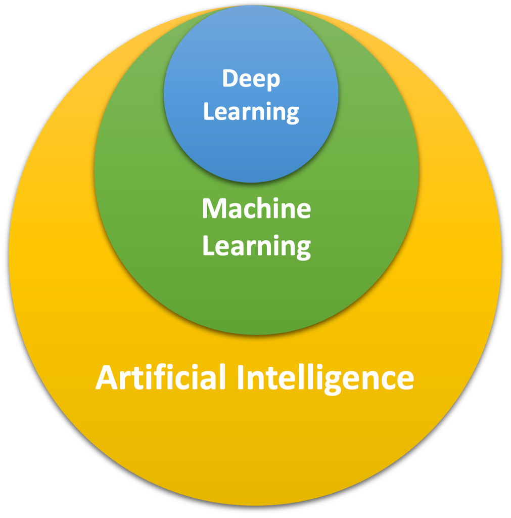

## Hierarchical Composition of Machine Learning

The **figure** below shows the hierarchical composition of machine learning and the subsets of machine learning. I have created this diagram, influenced by (Russell and Norvig, 2021), to show how machine learning operates. There are three forms of learning: supervised, unsupervised, and reinforcement learning, all subsets of machine learning. I will explore these subsets of machine learning and evaluate which type relates to my problem domain.

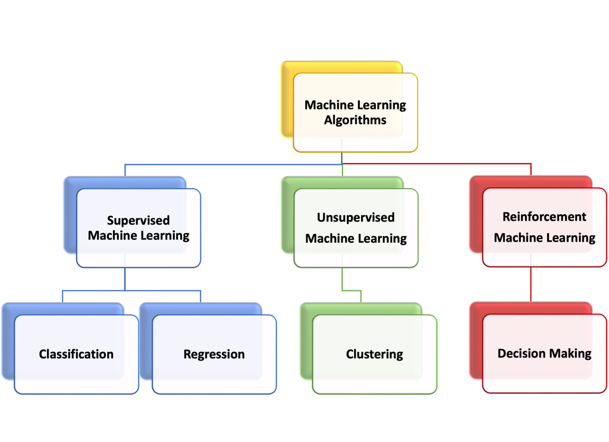

# Supervised learning

## Classification

**Classification** is “predicting a label” from a “discrete” dataset. (Blaine et al., 2020). Usually, we see examples of binary classification as these are straightforward, meaning it is or is not. In the "discrete" dataset (Blaine et al., 2020), the class labels are either 0 or 1. For instance, we could apply a detection of whether “a given email is spam or not” (Blaine et al., 2020) by teaching a model based on the labelled data found. multi-class classification is different as it has "more than two"(Grandini, Enrico Bagli and Giorgio Visani, 2020) class labels. Each number in the classifying label represents a "different class"(Grandini, Enrico Bagli and Giorgio Visani, 2020) or outcome. Different types of classification also exist, like multi-label and imbalanced classification; however, for my problem domain, I think I would need to explore further benefits of binary classification.

**Each classification algorithm has its optimisation techniques to fine-tune the model's parameters and enhance predictive performance. Understanding the nuances of each algorithm's optimization approach is crucial for achieving optimal model performance in various classification tasks. It's a dynamic landscape where the nature of the data and the problem at hand influence the choice of algorithm and the associated optimization strategies.**

### Real World examples:

- Email Spam
  - Predicts if "email is spam"; if authentic, it is delivered to "junk folder" (PennState: Statistics Online Courses, 2020)
- Handwritten digit detection
  - Images containing "single digits from 0-9" are converted to numerical data used in America to identify zip codes
  - The response is "multi-level and can take 10 values." (PennState: Statistics Online Courses, 2020)
- DNA Sequence Classification
  - classification of DNA segments into two categories; "coding or non-coding" (PennState: Statistics Online Courses, 2020)

### Algorithms related to classification include:

- Naïve Bayes classifier
- Decision tree
- Random Forest
- SVM (Support Vector Machine)
- KNN (K-Nearest Neighbour)
- Neural Networks

## Regression

**Regression** is described as a “task of estimating a continuous value” (Blaine et al., 2020). An example of this could be estimating the price of a business based on its “locations and dimensions as input data” (Blaine et al., 2020). Regression is used for "forecasting and prediction"(Maulud and Abdulazeez, 2020). regression analysis proves valuable in specific scenarios for establishing "causal relationships between independent and dependent variables" (Maulud and Abdulazeez, 2020). It is crucial to note that regressions, on their own, reveal associations exclusively between a "dependent variable and a fixed dataset collection of different variables" (Maulud and Abdulazeez, 2020). There are various regression examples; two important ones are linear and non-linear regression. One assumes a linear relationship between the "independent and dependent variables" (Maulud and Abdulazeez, 2020) by applying a linear equation. The relationship can also be described as a straight line. The other assumes the opposite association between "independent and dependent variables" (Maulud and Abdulazeez, 2020) by applying a non-linear equation accommodating complex and curved patterns in data.

### Real World examples:

- Financial Forecasting
- weather analysis and prediction
- time series forecasting

### Algorithms relating to regression include:

- Linear regression
- Neural network for regression
- SVM for regression
- Decision tree for regression
- Lasso regression
- Ridged regression

# Unsupervised learning

## Clustering

**Clustering** is a form of unsupervised learning, and it is the method of finding the “natural grouping” based on the “predefined properties of variables in the dataset”(Alok and Bradford, 2019). It uses “intuitive sense” (Alok and Bradford, 2019) to identify a variable to its group. clustering aims to keep similar data points together whilst keeping dissimilar data points separately. however, the model will not know the difference between the categories as the data is unlabeled compared to classification, where the model predicts outcomes based on labelled data. the "clusters or bunches" (Alok and Bradford, 2019) identified by the model will be determined by "the Euclidian distance" (Alok and Bradford, 2019) between them. Euclidian distance measures the "straight line distance between any two points", described as "the square root of the sum of squares of differences between the coordinates"(Alok and Bradford, 2019). It is a standard metric even though others exist, like the "Manhattan distance"(Alok and Bradford, 2019), which is the distance between two points "measured along a right angle to the axes"(Alok and Bradford, 2019) or the "sum of the absolute value of the differences" between the two points(Alok and Bradford, 2019). The model doesn't know the difference between the variables by name or description, but instead, it categorically identifies clusters based on the distance between two points.

### Real-world examples:

- Music recommendation systems
- Basket analysis
- Document analysis

### The algorithms entailed are:

(Alok and Bradford, 2019)

- K-Means Clustering
- Mean Shift Clustering
- DBSCAN Clustering
- Gaussian Mixture

# Reinforcement Learning

## Decision making

**Reinforcement Learning** is described as “Agents learning from experience”. (Russell and Norvig, 2021) This is compared to supervised learning, which learns passively from input data. The method of reinforcement learning can be described as decision-making. The agent in reinforcement learning is described as having an interaction with the world and "periodically receives rewards"(Russell and Norvig, 2021) that affect the behaviour of the agent to determine "how well it is doing"(Russell and Norvig, 2021). These are very different from the other two types of learning described before; unsupervised and supervised learning are trained on continuous and discrete datasets to predict outcomes. Meanwhile, reinforcement learning is training on the responses it receives from the world and making decisions based on the results. an example of this is if an agent is playing chess, "the reward is 1 for winning, 0 for losing and 1/2 for a draw" (Russell and Norvig, 2021). "Markov decision process can be considered as the basis theory" of reinforcement learning named after "Andrey Markov" (Gao, Chen & Mi 2022) a mathematical framework applied to represent decision-making scenarios with outcomes influenced by a combination of randomness and controllable factors.

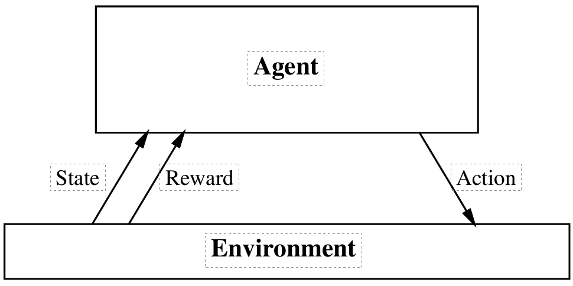

This **figure** represents how an agent learns to choose actions that maximise the reward.

### Real-world examples:

- Autonomous Cars
- Gaming
- Automated data centre cooling systems

### Algorithms relating to Reinforcement learning include:

- Reinforcement learning
- Q-Learning
- R-Learning
- TD-Learning

### Summary

In conclusion, as we navigate the expansive landscape of artificial intelligence, we find a direct application of these advanced techniques to our specific problem domain — predicting the survival outcomes of Titanic passengers.

Our journey through the hierarchical composition of machine learning, particularly in the realm of supervised learning and classification, unveils a rich toolkit of algorithms such as Naïve Bayes, Random Forest, K-Nearest Neighbors (KNN), Decision trees, and Neural Networks (MLP). These sophisticated AI models will guide us in deciphering patterns and extracting meaningful insights from the Titanic dataset.

By leveraging the power of machine learning, we aim to unravel the intricate relationships within the data and harness the predictive capabilities of these algorithms. The real-world examples, ranging from email spam detection to autonomous cars, showcase the versatility of these AI techniques, underlining their potential impact in solving complex problems.

As we embark on this project, the fusion of AI with our classification task opens new horizons for understanding and predicting survival outcomes, echoing the transformative role of artificial intelligence in unravelling insights from historical data.

## References:

- Cunningham, P., Cord, M. and Delany, S.J. (2008). Supervised Learning. Machine Learning Techniques for Multimedia, pp.21–49. doi:https://doi.org/10.1007/978-3-540-75171-7_2.
- Russell, S. and Norvig, P. (2021). Netscaler Gateway. [online] Proquest.com. Pearson Education, Limited. Available at: https://ebookcentral.proquest.com/lib/westminster/reader.action?docID=6563568 [Accessed 6 Dec. 2023].
- Blaine, B., Ashish Ranjan, J., Benjamin, J. and Ishita, M. (2020). The supervised learning workshop : a new interactive approach to understanding supervised learning algorithms. second ed. [online] authn.westminster.ac.uk. Birmingham, UK : Packt Publishing. Available at: https://ebookcentral.proquest.com/lib/westminster/reader.action?docID=6126527 [Accessed 6 Dec. 2023].
- Alok, M. and Bradford , T. (2019). Chapter 1 - Applied Unsupervised Learning with R [Book]. [online] www.oreilly.com. Birmingham : Packt Publishing Ltd. Available at: https://learning.oreilly.com/library/view/applied-unsupervised-learning/9781789956399/C12628_01_EPUB_Final_SZ.xhtml#_idParaDest-20 [Accessed 6 Dec. 2023].
- Grandini, M., Enrico Bagli and Giorgio Visani (2020). Metrics for Multi-Class Classification: an Overview. arXiv (Cornell University). doi:https://doi.org/10.48550/arxiv.2008.05756.
- PennState: Statistics Online Courses. (2020). 1(a).5 - Classification Problems in Real Life | STAT 508. [online] Available at: https://online.stat.psu.edu/stat508/lesson/1a/1a.5.
- Maulud, D. and Abdulazeez, A.M. (2020). A Review on Linear Regression Comprehensive in Machine Learning. Journal of Applied Science and Technology Trends, [online] 1(4), pp.140–147. doi:https://doi.org/10.38094/jastt1457.
- Gao, T., Chen, B., & Mi, Q. (2022). 'A Survey of Markov Model in Reinforcement Learning'. 2022 International Conference on Artificial Intelligence in Information and Communication (ICAIIC), Jeju Island, Korea. pp. 284-287. DOI: 10.1109/ICAIIC54071.2022.9722618.

# Part B - Compare and Evaluate AI techniques

## 1. Naïve Bayes

Naïve Bayes is categorised among the "family of simple probabilistic classifiers" within classification algorithms (Xu, 2016). The algorithm adopts a Naïve assumption that "all features are independent of each other," streamlining computations and demonstrating effectiveness in practical applications. However, this assumption's limitation is evident in its oversight of "dependencies among attributes" (Zhang, 2004), where another may influence the truth of one attribute. Despite this limitation, the Naïve Bayes approach excels in mitigating the challenges posed by the "curse of dimensionality" (Scikit-learn, 2019), mainly when "dependencies among attributes cancel each other out" (Zhang, 2004).

In examining real-world applications such as spam filtering, it becomes apparent that Naïve Bayes performs admirably even with a "small amount of training data to estimate necessary parameters" (Scikit-learn, 2019), reducing the risk of overfitting. Overfitting, a concern in larger, more complex models with numerous parameters, is less likely to occur due to the simplicity and computational efficiency of the Naïve Bayes method.

This classification technique has proven successful across diverse real-world scenarios, encompassing "text classification, keyphrase extraction, and medical diagnosis" (Xu, 2016). Its efficacy in handling "dependence distribution" contributes to its widespread adoption in addressing complex problems (Xu, 2016).

Naïve Bayes stands out for its swift setup, notably described as "extremely fast compared to sophisticated methods" (Scikit-learn, 2019). This stands in contrast to more intricate algorithms like neural networks, which necessitate a longer setup time and a waiting period for results. In my problem domain, leveraging Naïve Bayes involves opting for Gaussian Naïve Bayes. This choice is motivated by the dataset's adherence to a normal distribution and "continuous features" (Scikit-learn, 2019). The Gaussian Naïve Bayes algorithm excels in handling numerical data, aligning seamlessly with the dataset's characteristics.

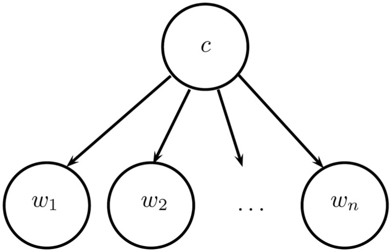

.

Xu, S. (2016). Bayesian Naïve Bayes classifiers to text classification. Journal of Information Science, 44(1), pp.48–59. doi:https://doi.org/10.1177/0165551516677946.

**This figure shows a bayesian network graph, where the arrows "indicate conditional dependencies between variables"(Xu, 2016)**

### 1.1. Application of Naïve Bayes algorithm to Titanic Survival Prediction

Applying this approach to Titanic Survival Prediction involves utilising features like age, gender, class, and other relevant passenger information. The method requires labelled data specifying whether passengers survived. The setup is quick and straightforward, facilitating rapid implementation. The training time is fast, making it suitable for swift analysis and predictions. The output of this process is binary predictions for each passenger, indicating whether they survived or did not survive the Titanic incident.

## 2. Random Forest

Random Forest has been deemed "extremely successful" in tackling classification and regression problems, rendering it a versatile and advantageous tool across various domains (Biau and Scornet, 2016). This is solely because of the "combination of its components", including "bagging and the classification and regression trees (CART)-split criterion" (Biau and Scornet, 2016). The algorithm operates by combining "several randomised decision trees" and their collective predictions are obtained through "aggregating the predictions through averaging" (Biau and Scornet, 2016). Noted for its "simplicity and effectiveness", Random Forest employs a "sampling fractions of data" approach, producing an average prediction (Biau and Scornet, 2016). This methodology underscores its significance in feature importance, enhancing accuracy for specific supervised learning problems. Recognised for its accuracy, Random Forest is celebrated for performing well even in "small sample sizes and high-dimensional feature spaces" within machine-learning contexts (Biau and Scornet, 2016).

However, because of the "combination of different components", we find it hard to interpret how the model works, and a reasonable description of the method can be like a "black box flavour of method" (Biau and Scornet, 2016). Additionally, with the combination of these components, bagging is a "computationally intensive procedure" used to "improve unstable estimates" (Biau and Scornet, 2016). From this, we can infer that the training time for random forests may take longer if the datasets are larger.

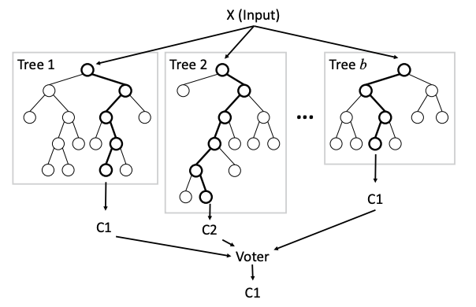

**This figure highlights the architrecture of random forests**

### 2.1. Application of Random Forest algorithm to Titanic Survival Prediction

In applying decision trees and ensemble methods for predicting Titanic survival, the input data includes features like age, gender, class, etc., resembling the Naïve Bayes approach. This method effectively uses labelled data, making it suitable for moderate to large-sized datasets. The setup phase entails configuring decision trees and ensemble parameters, requiring some time for optimal adjustment. While the training time may be longer compared to Naïve Bayes, it remains faster than the training time for Neural Networks. The ultimate output comprises binary predictions for each passenger, indicating whether they survived or did not survive the Titanic disaster.

## 3. Decision tree

A decision tree is an algorithm which "recursively partitions a dataset of records" until all samples in the dataset belong to a "particular class" or output(Jadhav and Channe, 2016). Techniques used for this process include "Depth-first search, greedy search and breadth-first search" which apply rules to expand nodes in the tree accordingly (Jadhav and Channe, 2016). In a decision tree, every node "denotes a test condition of an attribute", and it is structurally organised to have a "root node, internal and leaf nodes"(Jadhav and Channe, 2016). The root node is the first node in the tree and has no parent node, whereas every other node has at least one parent node, and every node can have as many children nodes as necessary. It follows a "divide and conquer technique" similar to the random forest, and each step the decision tree makes "forms a decision rule"(Jadhav and Channe, 2016).

Decision trees' advantage is that they are "very simple and fast" for the set-up and result in accurate predictions(Jadhav and Channe, 2016). The structure of a tree is "comprehensible", and it supports "incremental learning"(Jadhav and Channe, 2016). compared to other algorithms, it holds "less memory", and like the naive Bayes algorithm, it can "deal with noisy data"(Jadhav and Channe, 2016). finding the "best split attribute" using a variety of different measures like "entropy, gini index and information gain", which is advantageous (Jadhav and Channe, 2016).

The disadvantage of decision trees is that it can take significant time for the training phase, as described by (Jadhav and Channe, 2016), especially for large datasets due to the process of constructing the tree. Replication issues can lead to decision trees representing some concepts in a "complex" way, affecting the interoperability of the structure(Jadhav and Channe, 2016). Finally, decision trees are susceptible to "overfitting", resulting in reduced generalisation performance on new, unseen data (Jadhav and Channe, 2016).

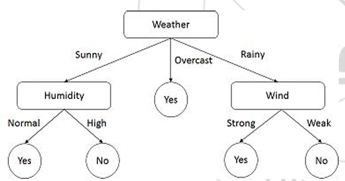

**This figure shows an example of "tree induction" (Jadhav and Channe, 2016).**

### 3.1. Application of Decision Trees to Titanic Survival Prediction:

Utilising features such as age, gender, class, sibling/spouse count, parent/child count, fare, and embarkation point to predict Titanic survival, this method applies to small to large-sized labelled datasets, contingent on the availability of survival information. The setup involves a moderate time investment, as decision trees necessitate constructing a tree structure during training, which may take longer than the minimal training required for KNN. However, once the decision tree is established, predicting survival outcomes for new data is efficient due to the straightforward traversal of the tree. The output consists of binary predictions for each passenger—indicating whether they survived or did not survive. Decision trees provide clear and interpretable rules contributing to the transparency of the predicted outcomes.

## 4. K-Nearest Neighbors (KNN)

Out of all the algorithms mentioned, KNN is one of the simplest algorithms to implement and understand. The algorithm is quite self-explanatory as it is based on the similarity between data points, and they are in "close vicinity" (Jadhav and Channe, 2016). KNN is a part of a family of "lazy learners", meaning they are "instance-based classifiers" (Jadhav and Channe, 2016). In the context of "lazy learners", the term "lazy" refers to the fact that these algorithms store all "training samples" and refrain from building a "classifier until a new, unlabeled sample" requires classification (Jadhav and Channe, 2016). This makes using KNN advantageous as there is no training phase, which makes it easy to adapt to new data. KNN takes less "computational time" in the training stage than other "eager-learning algorithms" like decision trees, neural networks and Bayes networks (Jadhav and Channe, 2016).

The performance of the KNN algorithm is affected by the "value of k", meaning if it is too small, then the algorithm may be "vulnerable to overfitting" due to "noise present in the dataset"(Jadhav and Channe, 2016). On the other hand, if the K value is too big, then the algorithm may "misclassify the test sample" due to similar points coinciding in faraway locations "from its neighbourhood" (Jadhav and Channe, 2016). KNN uses a metric called "Euclidian distance" to find these similarities between the data points and makes the conclusion based on the distance between the values (Jadhav and Channe, 2016).

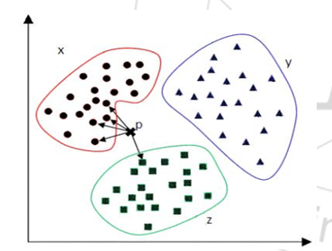

(Jadhav and Channe, 2016)

Strengths:

- Simple to comprehend and put into practice.
- Training happens quickly.
- It can withstand erratic training data.
- It functions effectively when a sample may have many class labels.

(Jadhav and Channe, 2016)

Weaknesses:

- When comparing a given unlabeled sample with many potential neighbours, lazy learners suffer significant computing costs.
- It is susceptible to the data's local structure.
- Memory restriction: It operates slowly since it is a supervised lazy learner.

  (Jadhav and Channe, 2016)

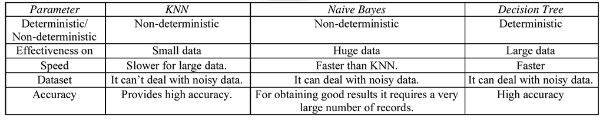

**This figure provided by (Jadhav and Channe, 2016) provides a useful comparison between three algorithms previously examined in this project**

### 4.1. Application of K-Nearest Neighbors (KNN) to Titanic Survival Prediction

Utilising features representing passenger information, this approach for predicting Titanic survival is well-suited for small to moderate-sized labelled datasets. The setup is characterised by a minimal training phase, ensuring a quick and straightforward configuration. However, the prediction time can be relatively high, particularly when dealing with large datasets. The ultimate output consists of binary predictions for each passenger, indicating whether or not they survived the Titanic incident.

## 5. Neural Networks (MLP)

One of the most widely used "neural network architectures" is the multi-layer perceptron, which is considered to have "lower complexity and ability to produce satisfactory results" for non-linear relationships (Hemalatha and Rani, 2017). Multilayer Perceptrons utilise "supervised learning" for predictive analysis and accurate results (Hemalatha and Rani, 2017). Multilayer perceptrons show strengths in handling "large quantities of training data" and various types of data, showing their advantageous qualities from their ability to handle complex relationships and suitability for large-scale problems. (Walde et al., 2004). However, this can become computationally expensive for deep architectures with many "neurons, layers and iterations" (Scikit-learn.org, 2023).

The non-convex nature of the loss function in Multi-layer Perceptrons (MLP) with hidden layers introduces "more than local minimum" (Scikit-learn.org, 2023). Consequently, distinct validation accuracies may arise due to "random weight initialisations" variations. Fine-tuning a multilayer perceptron can make it challenging to obtain the required accuracy. To achieve this one must go through a process of "tuning hyperparameters" such as the number of "neurons, layers and iterations" (Scikit-learn.org, 2023). Overfitting is a problem in neural networks and "other machine learning algorithms." it is the process where a model generalises well with new unseen data, and a multilayer perceptron is "susceptible to overfitting" if the model learns the training data too well. (Lawrence and Giles, 2000)

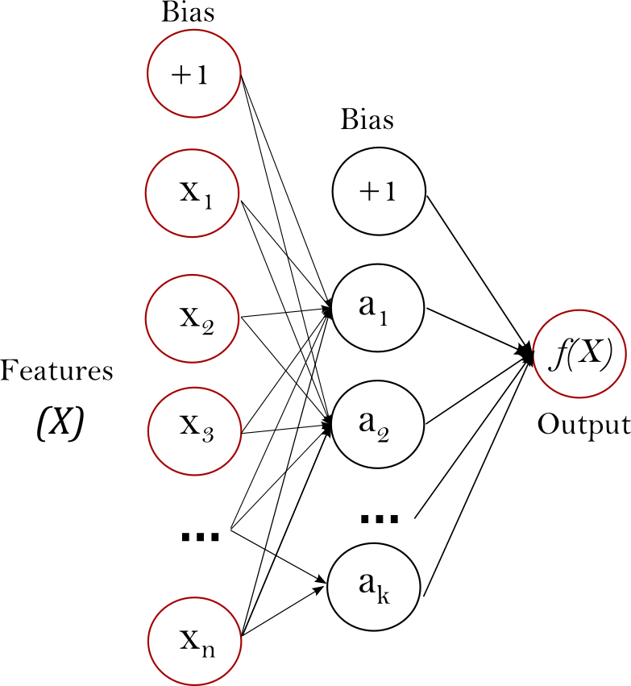

Scikit-learn.org. (2023). Available at: https://scikit-learn.org/stable/_images/multilayerperceptron_network.png [Accessed 28 Dec. 2023].

**This figure shows the architecture of a multilayer perceptron**

### 5.1. Application of Neural Networks (MLP) to Titanic Survival Prediction

Applying Neural Networks, specifically Multi-Layer Perceptrons (MLP), to predict Titanic survival involves utilising passenger characteristics as input features in a labelled dataset. This method is most effective with moderate to large-sized datasets. The setup process includes designing and configuring the neural network architecture, which may require some time for optimal configuration. Training the model can be time-consuming, especially for intricate architectures. Still, once trained, the neural network produces binary predictions for each passenger—indicating whether they survived or did not survive the Titanic disaster.

# Overall Comparison:

**Data Availability:**

- All techniques require a labelled dataset containing information on whether passengers survived. This information is crucial for training the models.

**Time to Setup and Produce Results:**

- Naïve Bayes and KNN: Quick setup and results, suitable for initial analyses.
- Random Forest: Balances speed and complexity, making it versatile for moderate-sized datasets.
- Neural Networks (MLP): This may require more time due to the setup of complex architectures.

**Output:**

- All techniques provide binary predictions, indicating whether a passenger will survive.

**Considerations:**

The choice of technique depends on various factors, including the dataset size, available computational resources, and the balance between simplicity and predictive performance. If quick insights are needed, Naïve Bayes or KNN might be preferable. Random Forest is a strong contender for a balance between speed and complexity. If accuracy is the primary focus and computational resources allow, Neural Networks (MLP) could be explored. Each method has its strengths and trade-offs, and the best choice will depend on the specific characteristics and goals of the Titanic survival prediction problem.

**Next stage:**

In the upcoming stage of the project, my goal is to delve deeper into the selected methods and assess their accuracy more comprehensively. I will strategically drop columns from the Titanic dataset that exhibit a weak correlation with the survival outcome to achieve this. After, I plan on implementing these algorithms and comparing their accuracy in predicting the desired outcome during testing. The algorithm that demonstrates the highest accuracy will be chosen as the most suitable solution for successfully addressing my classification problem.

## References

- Zhang, H. (2004). The Optimality of Naive Bayes. [online] Available at: https://www.cs.unb.ca/~hzhang/publications/FLAIRS04ZhangH.pdf.
- Xu, S. (2016). Bayesian Naïve Bayes classifiers to text classification. Journal of Information Science, 44(1), pp.48–59. doi:https://doi.org/10.1177/0165551516677946.
- Scikit-learn (2019). 1.9. Naive Bayes — scikit-learn 0.21.3 documentation. [online] Scikit-learn.org. Available at: https://scikit-learn.org/stable/modules/naive_bayes.html.
- Biau, G. and Scornet, E. (2016). A random forest guided tour. TEST, 25(2), pp.197–227. doi:https://doi.org/10.1007/s11749-016-0481-7.
- Jadhav, S.D. and Channe, H.P. (2016). Comparative Study of K-NN, Naive Bayes and Decision Tree Classification Techniques . International Journal of Science and Research (IJSR) , 5(1), pp.1842–1845.
- Hemalatha, K. and Rani, K.U., 2017. Advancements in multi-layer perceptron training to improve classification accuracy. International Journal on Recent and Innovation Trends in Computing and Communication, 5(6), pp.353-357.
- Scikit-learn.org (2023) Available at: https://scikit-learn.org/stable/_images/multilayerperceptron_network.png [Accessed 28 Dec. 2023].
- Walde, J.F., Tappeiner, G., Tappeiner, U., Tasser, E. and Holub, H.W. (2004). Statistical aspects of multilayer perceptrons under data limitations. Computational Statistics & Data Analysis, 46(1), pp.173–188. doi:https://doi.org/10.1016/s0167-9473(03)00140-3.
- Lawrence, S. and Giles, C. L., 2000. Overfitting and neural networks: conjugate gradient and backpropagation. In: Proceedings of the IEEE-INNS-ENNS International Joint Conference on Neural Networks (IJCNN 2000): Neural Computing: New Challenges and Perspectives for the New Millennium, Como, Italy, 2000. pp. 114-119 vol.1. DOI: 10.1109/IJCNN.2000.857823.

# FlowChart

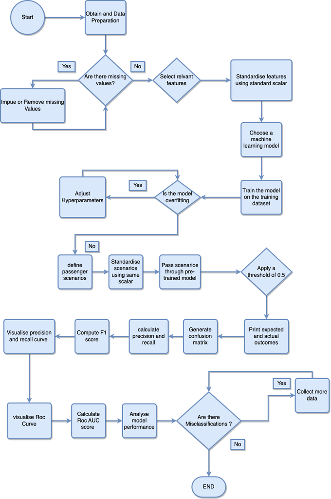

This is a high detailed flow chart showing the steps i intend to make in my project for a successful classification of my dataset.

# Preprocessing the data

### 1. Importing dependencies

```python
import numpy as np
import tensorflow as tf
from tensorflow import keras
import pandas as pd
from matplotlib import pyplot as plt
from sklearn.preprocessing import LabelEncoder
from sklearn.model_selection import train_test_split
from sklearn.preprocessing import StandardScaler

import seaborn as sns
import matplotlib.pyplot as plt
from sklearn.model_selection import cross_val_predict
from sklearn.metrics import confusion_matrix


from sklearn.metrics import precision_score, recall_score
%matplotlib inline
```

[output not shown]

### 2. Loading the dataset

```python
path = "titanic.xls"
data = pd.read_excel(path)
```

https://github.com/PinkWink/ML_tutorial/blob/master/dataset/titanic.xls

I found my dataset from Git Hub, as stated above.

I converted the dataset from Excel to CSV for simplicity, compatibility, and efficiency. CSV files are lightweight, platform-independent, and easily integrated into various data analysis tools. This conversion streamlines data handling, reduces file size, and ensures broader compatibility, making it easier to share and work with the dataset across different platforms and tools.

### 3. Converting excel file to csv

```python
data_csv = "titanic.csv"
data.to_csv(data_csv, index=False)
data.head()
```

|  | pclass | survived | name | sex | age | sibsp | parch | ticket | fare | cabin | embarked | boat | body | home.dest |
| --- | --- | --- | --- | --- | --- | --- | --- | --- | --- | --- | --- | --- | --- | --- |
| 0 | 1 | 1 | Allen, Miss. Elisabeth Walton | female | 29.0000 | 0 | 0 | 24160 | 211.3375 | B5 | S | 2 | NaN | St Louis, MO |
| 1 | 1 | 1 | Allison, Master. Hudson Trevor | male | 0.9167 | 1 | 2 | 113781 | 151.5500 | C22 C26 | S | 11 | NaN | Montreal, PQ / Chesterville, ON |
| 2 | 1 | 0 | Allison, Miss. Helen Loraine | female | 2.0000 | 1 | 2 | 113781 | 151.5500 | C22 C26 | S | NaN | NaN | Montreal, PQ / Chesterville, ON |
| 3 | 1 | 0 | Allison, Mr. Hudson Joshua Creighton | male | 30.0000 | 1 | 2 | 113781 | 151.5500 | C22 C26 | S | NaN | 135.0 | Montreal, PQ / Chesterville, ON |
| 4 | 1 | 0 | Allison, Mrs. Hudson J C (Bessie Waldo Daniels) | female | 25.0000 | 1 | 2 | 113781 | 151.5500 | C22 C26 | S | NaN | NaN | Montreal, PQ / Chesterville, ON |

```python
data.tail()
```

|  | pclass | survived | name | sex | age | sibsp | parch | ticket | fare | cabin | embarked | boat | body | home.dest |
| --- | --- | --- | --- | --- | --- | --- | --- | --- | --- | --- | --- | --- | --- | --- |
| 1304 | 3 | 0 | Zabour, Miss. Hileni | female | 14.5 | 1 | 0 | 2665 | 14.4542 | NaN | C | NaN | 328.0 | NaN |
| 1305 | 3 | 0 | Zabour, Miss. Thamine | female | NaN | 1 | 0 | 2665 | 14.4542 | NaN | C | NaN | NaN | NaN |
| 1306 | 3 | 0 | Zakarian, Mr. Mapriededer | male | 26.5 | 0 | 0 | 2656 | 7.2250 | NaN | C | NaN | 304.0 | NaN |
| 1307 | 3 | 0 | Zakarian, Mr. Ortin | male | 27.0 | 0 | 0 | 2670 | 7.2250 | NaN | C | NaN | NaN | NaN |
| 1308 | 3 | 0 | Zimmerman, Mr. Leo | male | 29.0 | 0 | 0 | 315082 | 7.8750 | NaN | S | NaN | NaN | NaN |

### 4. Finding the shape of the dataframe

Determining the shape of the DataFrame, accomplished through the data.shape command, reveals essential information about the dataset's structure. In this specific case, the DataFrame comprises 1309 rows and 14 columns. Understanding the dimensions of the dataset is crucial for assessing its size and complexity, providing a foundational understanding for subsequent data exploration and analysis tasks.

```python
data.shape
```

```
(1309, 14)
```

### 5. Understanding the dataset

### 5.1 Getting information of dataset

The dataset comprises 1309 entries with 14 columns. These columns encompass various attributes such as passenger class (pclass), survival status (survived), name, gender (sex), age, sibling/spouse count (sibsp), parent/child count (parch), ticket details (ticket), fare, cabin information (cabin), port of embarkation (embarked), lifeboat details (boat), body identification (body), and home/destination (home.dest).

```python
data.info()
```

```
<class 'pandas.core.frame.DataFrame'>
RangeIndex: 1309 entries, 0 to 1308
Data columns (total 14 columns):
 #   Column     Non-Null Count  Dtype
---  ------     --------------  -----
 0   pclass     1309 non-null   int64
 1   survived   1309 non-null   int64
 2   name       1309 non-null   object
 3   sex        1309 non-null   object
 4   age        1046 non-null   float64
 5   sibsp      1309 non-null   int64
 6   parch      1309 non-null   int64
 7   ticket     1309 non-null   object
 8   fare       1308 non-null   float64
 9   cabin      295 non-null    object
 10  embarked   1307 non-null   object
 11  boat       486 non-null    object
 12  body       121 non-null    float64
 13  home.dest  745 non-null    object
dtypes: float64(3), int64(4), object(7)
memory usage: 143.3+ KB
```

### 5.2 isnotnull.sum finding missing values

To comprehend the data completeness, I examined missing values using the isnull().sum() method. Notably, columns like age, cabin, fare, embarked, boat, body, and home.dest exhibit varying degrees of missing information.

```python
data.isnull().sum()
```

```
pclass          0
survived        0
name            0
sex             0
age           263
sibsp           0
parch           0
ticket          0
fare            1
cabin        1014
embarked        2
boat          823
body         1188
home.dest     564
dtype: int64
```

### 5.3 Correlation with survival

I explored the correlation between numeric features and the 'survived' column. Notably, the 'fare' and 'parch' variables show positive correlations with survival, while 'pclass' indicates a negative correlation.

I still need to change some of the features to a normalised form, meaning for some features, I can switch from text to numerical form and then once again check the correlation between survived and the other features.

```python
numeric_data = data.select_dtypes(include=['int64', 'float64'])
correlation_result = numeric_data.corr()['survived'].sort_values(ascending=False)

correlation_result
```

```
survived    1.000000
fare        0.244265
parch       0.082660
sibsp      -0.027825
age        -0.055513
pclass     -0.312469
body             NaN
Name: survived, dtype: float64
```

In summary, the refined dataset focuses on key features, ensuring relevance and data integrity for our predictive analysis.

### 6. Removing unwanted columns

I removed unnecessary columns to streamline the dataset, focusing on essential information for more efficient analysis.

- "name"
- "ticket"
- "boat"
- "body"
- "home.dest"
- "Cabin"
- "embarked"

```python
columns_toDrop = ["name","ticket","boat", "body","home.dest","cabin", "embarked"]
data.drop(columns=columns_toDrop, inplace=True)
```

### 7. Re-check existing information of datasets

Following removing unnecessary columns, a re-check of the dataset using data.info() reveals that the DataFrame now consists of 1309 entries and seven columns. The retained columns include 'pclass,' 'survived,' 'sex,' 'age,' 'sibsp,' 'parch,' and 'fare.' This concise summary provides an updated dataset snapshot, highlighting the essential information necessary for subsequent analysis.

Notably, some values in the 'age' and 'fare' columns missing, indicating areas that may require further attention during data preprocessing. This refined dataset is more focused and streamlined, setting the stage for meaningful analysis.

```python
data.info()
```

```
<class 'pandas.core.frame.DataFrame'>
RangeIndex: 1309 entries, 0 to 1308
Data columns (total 7 columns):
 #   Column    Non-Null Count  Dtype
---  ------    --------------  -----
 0   pclass    1309 non-null   int64
 1   survived  1309 non-null   int64
 2   sex       1309 non-null   object
 3   age       1046 non-null   float64
 4   sibsp     1309 non-null   int64
 5   parch     1309 non-null   int64
 6   fare      1308 non-null   float64
dtypes: float64(2), int64(4), object(1)
memory usage: 71.7+ KB
```

### 8. Converting text value into a numerical value

My process consists of using features in the dataset to handle the missing data in the age; the preprocessing of the dataset is essential for the data analysis tools I will use. The RandomForestRegressor() can not handle values which are not either float or integers. The initial step is to address this by converting the values for sex, male and female, to numerical values, ones and zeros.

```python
data['sex'] = data['sex'].replace({'male': 1, 'female': 0})
```

### 9. Fix missing value for fare

Fare has one missing value, as I have noticed from the data.info(). I must handle the missing single value before we can include the feature for the prediction of the age to avoid any errors. If I used this feature with even one value missing, the error would state that "Input X contains NaN." highlighting the importance of handling missing data in machine learning and how essential it is to the progress of the prediction. I do this using the average and placing it inside the column missing the value for the "Fare."

```python
mean_fare = data["fare"].mean()
data["fare"].fillna(mean_fare, inplace=True)
```

### 10. Fixing missing values from age

**There are several methods for handling missing age data in the Titanic dataset when predicting survivors. Here are some of the most common approaches:**

**10.1. Dropping passengers with missing age data:**

- Removing the whole columns where the age is missing
- This is the simplest method, but it can lead to a loss of information and a reduction in the dataset size.

**10.2. Imputation with mean or median:**

- This involves replacing the missing age values with the mean or median age of the entire dataset.
- This method is simple, but it can introduce bias if the distribution of missing values differs from that of observed values.

**10.3. Imputation with K-Nearest Neighbors (KNN):**

- This method involves finding the k nearest neighbors (i.e., passengers with similar characteristics) for each passenger with missing age data.
- The missing age value is then replaced with the average or median age of these k nearest neighbors.
- KNN is a more sophisticated method than imputation with mean or median, and it can handle nonlinear relationships between variables.

**10.4. Imputation with multiple imputation:**

- This method involves creating multiple imputed datasets, each with a different set of imputed values for the missing age data.
- The results of multiple imputation are then combined to obtain more robust estimates.

**10.5. Using a machine learning model to predict missing age data:**

```python
import pandas as pd
from sklearn.model_selection import train_test_split
from sklearn.ensemble import RandomForestRegressor
from sklearn.preprocessing import MinMaxScaler


# Separate passengers with missing age data from those with complete age data
passengers_with_missing_age = data[data['age'].isnull()]
passengers_with_complete_age = data[data['age'].notnull()]

# Select features for predicting missing age data
features = ['pclass', 'sex', 'sibsp', 'parch', 'fare']

# Create training and testing sets for the machine learning model
X_train = passengers_with_complete_age[features]
y_train = passengers_with_complete_age['age']

# Train a Random Forest regressor
regressor = RandomForestRegressor()
regressor.fit(X_train, y_train)

# Predict missing age data using the trained model
X_test = passengers_with_missing_age[features]
predicted_age = regressor.predict(X_test)

# Replace missing age values with predicted age values
data.loc[data['age'].isnull(), 'age'] = predicted_age

# Save the updated dataset
data.to_csv('train_with_predicted_age.csv')
```

### 11. Info to check whether missing values are fixed

- After these operations, a check of the dataset using data.info() was performed to ensure that missing values were effectively handled and that the dataset now contains 1309 entries with 7 columns.
- The 'age' column, in particular, is complete with no missing values, reflecting the success of the imputation process.
- to further emphasise, the dataset is now clean with no missing values, and all values are numerical. Essentially, this is ready for my prediction analysis, but before that, I may still need to take a couple of steps.

```python
data.info()
```

```
<class 'pandas.core.frame.DataFrame'>
RangeIndex: 1309 entries, 0 to 1308
Data columns (total 7 columns):
 #   Column    Non-Null Count  Dtype
---  ------    --------------  -----
 0   pclass    1309 non-null   int64
 1   survived  1309 non-null   int64
 2   sex       1309 non-null   int64
 3   age       1309 non-null   float64
 4   sibsp     1309 non-null   int64
 5   parch     1309 non-null   int64
 6   fare      1309 non-null   float64
dtypes: float64(2), int64(5)
memory usage: 71.7 KB
```

### 12. Merging sibling and parch to be family size

```python
 data['Family_Size'] = data['sibsp'] + data['parch']
data.drop(['sibsp', 'parch'], axis=1, inplace=True)
```

### 13. Normalisation

```python
data.head()
```

|  | pclass | survived | sex | age | fare | Family_Size |
| --- | --- | --- | --- | --- | --- | --- |
| 0 | 1 | 1 | 0 | 29.0000 | 211.3375 | 0 |
| 1 | 1 | 1 | 1 | 0.9167 | 151.5500 | 3 |
| 2 | 1 | 0 | 0 | 2.0000 | 151.5500 | 3 |
| 3 | 1 | 0 | 1 | 30.0000 | 151.5500 | 3 |
| 4 | 1 | 0 | 0 | 25.0000 | 151.5500 | 3 |

```python
from sklearn.preprocessing import StandardScaler

# Normalize numerical features
scaler = StandardScaler()
data[['age', 'fare']] = scaler.fit_transform(data[['age', 'fare']])
#data[[ 'fare']] = scaler.fit_transform(data[[ 'fare']])
```

### 14. Checking correlation again

**Correlation analysis, as demonstrated by the code data.corr()['survived'].sort_values(ascending=False), helps to understand the relationships between different features and the target variable ('survived' in this case). Here's a breakdown of the correlation values:**

```python
data.corr()['survived'].sort_values(ascending=False)
```

```
survived       1.000000
fare           0.244208
Family_Size    0.026876
age           -0.055391
pclass        -0.312469
sex           -0.528693
Name: survived, dtype: float64
```

**14.1 Positive Correlation:**

A positive correlation close to 1 suggests that as the value of a feature increases, the likelihood of survival also increases. In this dataset:

- 'fare' has a positive correlation of 0.244, indicating that higher fares are associated with a higher chance of survival.
- 'Family_Size' has a positive correlation of 0.027, suggesting a slight positive relationship, but it's not very strong.

**14.2 Negative Correlation:**

A negative correlation close to -1 suggests that as the value of a feature increases, the likelihood of survival decreases. In this dataset:

- 'pclass' has a negative correlation of -0.312, indicating that being in a lower passenger class is associated with a lower chance of survival.
- 'sex' (coded as 0 for female and 1 for male) has a strong negative correlation of -0.529, suggesting that being female is associated with a higher chance of survival

**14.3 weak correlation:**

- 'age' has a weak negative correlation of -0.054, indicating a very subtle relationship where older age might be slightly associated with lower chances of survival.

Understanding these correlations can guide feature selection for machine learning models. For instance, features with strong correlations (either positive or negative) may have more predictive power and could be essential for accurate model training. In contrast, features with weak correlations may contribute less to predicting the target variable and might be considered for further evaluation or exclusion.

In summary, correlation analysis provides insights into which features are likely to be influential in predicting survival, aiding in the selection and interpretation of features for machine learning models.

### 15. Saving the clean data

- The dataset, now cleaned and preprocessed, is saved to a CSV file named 'titanic.csv' using the code data.to_csv('titanic.csv', index=False). This step ensures that the changes made during preprocessing are preserved for future use and analysis.

```python
data.to_csv('titanic.csv', index=False)
```

### 16. Descriptive Statistics:

**Descriptive statistics, as shown in data.describe(), summarise the main statistical measures for each numerical column in the dataset.**

**Key statistics include:**

- Count: Number of non-null entries.
- Mean: The average value.
- Std (Standard Deviation): A measure of variation or dispersion.
- Min: The minimum value.
- 25%: The first quartile or 25th percentile.
- 50% (Median): The second quartile or median.
- 75%: The third quartile or 75th percentile.
- Max: The maximum value.

```python
data.describe()
```

|  | pclass | survived | sex | age | fare | Family_Size |
| --- | --- | --- | --- | --- | --- | --- |
| count | 1309.000000 | 1309.000000 | 1309.000000 | 1.309000e+03 | 1.309000e+03 | 1309.000000 |
| mean | 2.294882 | 0.381971 | 0.644003 | 2.388379e-16 | 4.342507e-17 | 0.883881 |
| std | 0.837836 | 0.486055 | 0.478997 | 1.000382e+00 | 1.000382e+00 | 1.583639 |
| min | 1.000000 | 0.000000 | 0.000000 | -2.200678e+00 | -6.437751e-01 | 0.000000 |
| 25% | 2.000000 | 0.000000 | 0.000000 | -6.031797e-01 | -4.911082e-01 | 0.000000 |
| 50% | 3.000000 | 0.000000 | 1.000000 | -1.388633e-01 | -3.643001e-01 | 0.000000 |
| 75% | 3.000000 | 1.000000 | 1.000000 | 5.839258e-01 | -3.906640e-02 | 1.000000 |
| max | 3.000000 | 1.000000 | 1.000000 | 3.713155e+00 | 9.262219e+00 | 10.000000 |

**Interpretation:**

- The 'pclass' column has values ranging from 1 to 3, averaging approximately 2.29.
- The 'survived' column is binary, with a mean of 0.38, indicating that around 38% of passengers survived.
- The 'sex' column, represented numerically (0 for female, 1 for male), has a mean of 0.64.
- The 'age' and 'fare' columns have been normalised, with means close to 0 and standard deviations around 1.
- 'Family_Size' has a maximum value of 10, suggesting a large family size for some passengers.

These statistics offer a quick overview of the central tendency and distribution of numerical features in the cleaned dataset, aiding in understanding the characteristics of the data.

### 16. Partition of features and label data

```python
x = data.drop('survived', axis = 1)
y = data['survived']
```

### 17. Partition of test and training data

```python
 x_train, x_test, y_train, y_test = train_test_split(x, y, test_size = 0.2, random_state = 123)
```

# 18. Implementing the model

### creating multiple variations

While implementing my multilayer perceptron, I encountered a challenge where the model's accuracy consistently averaged around 80%. Given my higher target accuracy, I initiated a hyperparameter tuning stage. This process involved adjusting key parameters such as the number of neurons, the configuration of hidden layers, and fine-tuning the learning rate. The objective was to systematically explore these hyperparameter variations to determine if any adjustments could elevate the model's accuracy beyond the 80% threshold.

## 18.1 Building Model

```python
model = tf.keras.models.Sequential([
    tf.keras.layers.Flatten(input_dim=5),
    tf.keras.layers.Dense(16, activation='relu'),
    tf.keras.layers.Dense(32, activation='relu'),
    tf.keras.layers.Dense(64, activation='relu'),
    tf.keras.layers.Dense(128, activation='relu'),
    tf.keras.layers.Dense(256, activation='relu'),
    tf.keras.layers.Dense(128, activation='relu'),
    tf.keras.layers.Dense(64, activation='relu'),
    tf.keras.layers.Dense(16, activation='relu'),
    tf.keras.layers.Dropout(0.5),  # Remove the extra parenthesis here
    tf.keras.layers.Dense(1, activation='sigmoid')
])
# average accuracy around 80%

model1 = keras.Sequential([
    keras.layers.Dense(64, activation='relu', input_shape=(5,)),
    keras.layers.Dropout(0.3),
    keras.layers.Dense(32, activation='relu'),
    keras.layers.Dense(16, activation='relu'),
    keras.layers.Dropout(0.3),
    keras.layers.Dense(1, activation='sigmoid')
])
# accuracy around 80%


model2 = keras.Sequential([
    keras.layers.Dense(128, activation='relu', input_shape=(5,)),
    keras.layers.Dropout(0.5),
    keras.layers.Dense(64, activation='relu'),
    keras.layers.Dense(32, activation='relu'),
    keras.layers.Dropout(0.5),
    keras.layers.Dense(1, activation='sigmoid')
])

# accuracy around 82%


model3 = keras.Sequential([
    keras.layers.Dense(64, activation='relu', input_shape=(5,)),
    keras.layers.Dropout(0.25),
    keras.layers.Dense(64, activation='relu'),
    keras.layers.Dropout(0.25),
    keras.layers.Dense(32, activation='relu'),
    keras.layers.Dense(16, activation='relu'),
    keras.layers.Dropout(0.25),
    keras.layers.Dense(1, activation='sigmoid')
])
# accuracy around 81%


model4 = keras.Sequential([
    keras.layers.Dense(128, activation='relu', input_shape=(5,)),
    keras.layers.Dropout(0.4),
    keras.layers.Dense(64, activation='relu'),
    keras.layers.Dropout(0.4),
    keras.layers.Dense(32, activation='relu'),
    keras.layers.Dense(16, activation='relu'),
    keras.layers.Dropout(0.4),
    keras.layers.Dense(1, activation='sigmoid')
])

# accuracy of 81.68%
model5 = keras.Sequential([
    keras.layers.Dense(64, activation='relu', input_shape=(5,)),
    keras.layers.Dense(128, activation='relu'),
    keras.layers.Dropout(0.3),
    keras.layers.Dense(64, activation='relu'),
    keras.layers.Dropout(0.3),
    keras.layers.Dense(32, activation='relu'),
    keras.layers.Dense(16, activation='relu'),
    keras.layers.Dropout(0.3),
    keras.layers.Dense(1, activation='sigmoid')
])

# accuracy of 81.68

model6 = keras.Sequential([
    keras.layers.Dense(64, activation='relu', input_shape=(5,)),
    keras.layers.Dense(32, activation='relu'),
    keras.layers.Dropout(0.25),
    keras.layers.Dense(32, activation='relu'),
    keras.layers.Dense(16, activation='relu'),
    keras.layers.Dropout(0.25),
    keras.layers.Dense(1, activation='sigmoid')
])

#accuracy of 82.44%

model7 = keras.Sequential([
    keras.layers.Dense(128, activation='relu', input_shape=(5,)),
    keras.layers.Dropout(0.5),
    keras.layers.Dense(64, activation='relu'),
    keras.layers.Dropout(0.5),
    keras.layers.Dense(32, activation='relu'),
    keras.layers.Dense(1, activation='sigmoid')
])

#81.30%



# Simple Model
simple_model = keras.Sequential([
    keras.layers.Dense(32, activation='relu', input_shape=(5,)),
    keras.layers.Dense(1, activation='sigmoid')
])
```

## 18.2 Compliling model

At this stage, I'm compiling the model and obtaining a summary that illustrates the architecture of the multilayer perceptron. To explore the impact of different model variations mentioned above, I systematically replaced the variable name "model" with the names corresponding to various model variations. By evaluating the accuracy results, I aimed to discern whether modifying specific aspects of the architecture would yield differences in the accuracy values.

```python
simple_model.compile(optimizer='adam', loss='binary_crossentropy', metrics=['accuracy'])


simple_model.summary()
```

```
Model: "sequential_16"
_________________________________________________________________
 Layer (type)                Output Shape              Param #
=================================================================
 dense_84 (Dense)            (None, 32)                192

 dense_85 (Dense)            (None, 1)                 33

=================================================================
Total params: 225 (900.00 Byte)
Trainable params: 225 (900.00 Byte)
Non-trainable params: 0 (0.00 Byte)
_________________________________________________________________
```

## 18.3 Training Stage

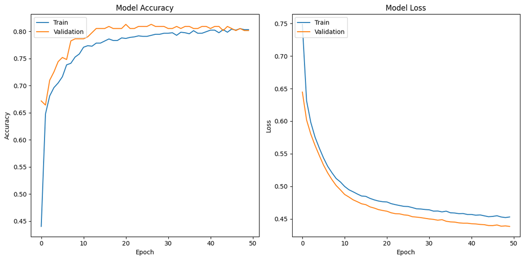

```python
hist = simple_model.fit(x_train,
                 y_train,
                 validation_data = (x_test, y_test),
                 epochs = 50,
                 batch_size = 20)


# Visualize training history
plt.figure(figsize=(12, 6))

# Plot training & validation accuracy values
plt.subplot(1, 2, 1)
plt.plot(hist.history['accuracy'])
plt.plot(hist.history['val_accuracy'])
plt.title('Model Accuracy')
plt.xlabel('Epoch')
plt.ylabel('Accuracy')
plt.legend(['Train', 'Validation'], loc='upper left')

# Plot training & validation loss values
plt.subplot(1, 2, 2)
plt.plot(hist.history['loss'])
plt.plot(hist.history['val_loss'])
plt.title('Model Loss')
plt.xlabel('Epoch')
plt.ylabel('Loss')
plt.legend(['Train', 'Validation'], loc='upper left')

plt.tight_layout()
plt.show()
```

### 18.4 Evaluating Graphs Relating To Models Accuracy and Loss

This graph shows the model's performance by visualising the accuracy and loss against the performance on the training in blue and orange tests. Model accuracy shows a promising curve in the training and the validation data, although it is quite steep to begin with, indicating that it is learning from the dataset swiftly. The line presented for the loss shows a negative correlation for each epoch, indicating the model learning from the dataset as the error decreases. although it has yet to reach 100% for my accuracy or 0 for my model loss, I feel satisfied that the model is not showing signs of overfitting.

### 18.5 Evaluating Models Training And Test Accuracy & Loss

I'm evaluating the neural network's performance on a separate test dataset at this stage. Using the model.evaluate() function, I calculate the test loss and accuracy. The test loss shows how well the model generalises to new, unseen data, aiming for a lower value for better performance. The test accuracy represents the percentage of correctly classified instances in the test set, measuring the model's effectiveness. The printed results, including the formatted test loss and accuracy, clearly understand the neural network's real-world performance.

```python
# Evaluate model on training set
train_loss, train_accuracy = simple_model.evaluate(x_train, y_train, verbose=0)
train_accuracy_percentage = round(train_accuracy * 100, 2)

# Evaluate model on test set
test_loss, test_accuracy = simple_model.evaluate(x_test, y_test)

# Print results
print("Accuracy on training:", train_accuracy_percentage, "%")
print(f'Test Loss: {test_loss:.4f}')
print(f'Test Accuracy: {test_accuracy * 100:.2f}%')
```

```
Accuracy on training: 80.04 %
Test Loss: 0.4384
Test Accuracy: 80.15%
```

## 19. Testing

In this code, I utilised a machine learning model to predict the likelihood of survival for various passenger scenarios. These scenarios include different combinations of features such as passenger class, sex, age, fare, and family size. To ensure consistent input, I standardised the scenarios using Scikit-learn's StandardScaler. After standardisation, the data was passed through the pre-trained model, which had been previously developed to predict survival outcomes. By applying a threshold of 0.5, the model's probability predictions were converted into binary outcomes, indicating whether a passenger survived or did not survive. The final step involved printing the expected and actual outcomes for each scenario, offering insights into the model's predictions based on the provided input features.

```python
import numpy as np
from sklearn.preprocessing import StandardScaler

# Define the scenarios with input features
scenarios = [

    [3, 1, 39, 31.275, 6], # 1 expected non survived
    [3, 1, 27, 7.7958, 0], # 2 expected  survived
    [2, 0, 4, 23, 2], # 3 expected  survived
    [2, 0, 29, 23, 2], # 4 expected  survived
    [1, 1, 62, 26.55, 0], # 5 expected non survived
    [1, 1, 39, 135.6333, 0] # 6 expected survived

]




# Convert scenarios to numpy array
scenarios_np = np.array(scenarios)

# Standardise input features if necessary (use the same scaling as during training)
sc = StandardScaler()
normalized_scenarios = sc.fit_transform(scenarios_np)

# Use the trained model to predict outcomes
predictions = simple_model.predict(normalized_scenarios)

# Convert predictions to binary outcomes (0 or 1)
binary_predictions = (predictions > 0.5).astype(int)

# Print the results
for i in range(len(scenarios)):
    print(f"\nScenario {i + 1}:")

    print(f"Actual Outcome: {'Survived' if binary_predictions[i] == 1 else 'Did Not Survive'}")
```

```
Scenario 1:
Actual Outcome: Did Not Survive

Scenario 2:
Actual Outcome: Did Not Survive

Scenario 3:
Actual Outcome: Survived

Scenario 4:
Actual Outcome: Survived

Scenario 5:
Actual Outcome: Survived

Scenario 6:
Actual Outcome: Survived
```

In evaluating the model's performance using random passenger scenarios from the dataset, the outcomes revealed a moderately accurate prediction rate of 4 out of 6 scenarios. The model accurately predicted survival outcomes in scenarios 1, 3, 4 and 6, showcasing its proficiency in various situations. However, scenarios 2 and 5 resulted in misclassifications, particularly in predicting non-survival. This observation highlights potential limitations in handling certain passenger profiles. I want you to know that reflecting on these results underscores the need for ongoing refinement and exploration of additional features or techniques to improve accuracy, especially in higher complexity or ambiguity scenarios. While the model demonstrated commendable performance in most scenarios, continuous optimisation efforts are essential to address specific challenges encountered during testing. This iterative process will enhance the model's predictive capabilities and overall reliability.

I encountered various challenges throughout the model development, particularly in hyperparameter tuning and dataset adjustments. Experimenting with different configurations and fine-tuning hyperparameters was a complex yet crucial step in optimising the model's performance. Despite the difficulties, it was gratifying to witness that the model maintained a balanced performance without succumbing to overfitting. The achieved average accuracy of around 80% on the training and testing datasets reflects a robust and generalisable model. This balance instils confidence in the model's ability to make accurate predictions on unseen data. The iterative nature of these adjustments underscored the importance of meticulous tuning, reinforcing that achieving a well-performing model requires a combination of experimentation, persistence, and a deep understanding of the dataset dynamics. These experiences not only enriched my understanding of machine learning but also highlighted the dynamic nature of the model development process

# 20. Evaluation of MLP

## 20.1 Evaluating Based on Confusion Matrix / Cross Validation

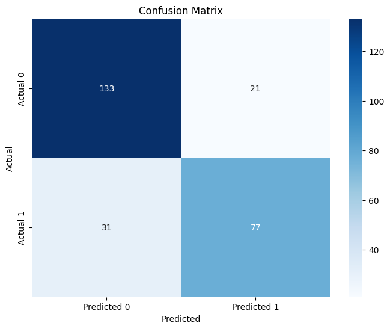

```
[[133  21]
 [ 31  77]]
```

```python
# Predicting using the trained Keras model
y_pred = np.round(simple_model.predict(x_test)).astype(int)

# Creating the confusion matrix
cm = confusion_matrix(y_test, y_pred)

# Creating a Seaborn heatmap for the confusion matrix
plt.figure(figsize=(8, 6))
sns.heatmap(cm, annot=True, fmt='d', cmap='Blues', xticklabels=['Predicted 0', 'Predicted 1'], yticklabels=['Actual 0', 'Actual 1'])
plt.ylabel('Actual')
plt.xlabel('Predicted')
plt.title('Confusion Matrix')
plt.show()
print(cm)
```

These values are crucial for understanding the strengths and weaknesses of the model in terms of both positive and negative predictions. From these values, I can calculate various metrics such as accuracy, precision, recall, and F1 score, which provide insights into the performance of my classification model.

## 20.2 Evaluating imbalanced Class Labels

```python
# Check class distribution
print(y.value_counts())
```

```
survived
0    809
1    500
Name: count, dtype: int64
```

While building and evaluating various models for predicting survival on the Titanic, a notable observation emerged regarding the class label distribution. The dataset exhibited a significant imbalance between passengers who survived and those who did not, with 809 instances of non-survival compared to 500 instances of survival. This imbalance posed a challenge during model training, as the algorithms tended to predict the majority class more frequently, leading to an increased number of false negat ives in the confusion matrix. The model struggled to identify survival instances, resulting in a higher misclassification rate for positive cases.

## 20.3 Evaluating Based on Precision and Recall

In this stage, precision and recall metrics are computed to assess the Keras model's performance on the test dataset. Precision quantifies the accuracy of positive predictions, indicating how often the model correctly identifies positive instances. Recall, on the other hand, gauges the model's ability to capture all actual positive instances. These metrics offer a more detailed evaluation of the model's classification accuracy, particularly in binary classification. The printed results provide numerical values for precision and recall, concisely interpreting the model's predictive capabilities.

```python
# Calculate precision and recall
precision = precision_score(y_test, y_pred)
recall = recall_score(y_test, y_pred)



# Print the results
print("Precision:", precision)
print("Recall:", recall)
```

```
Precision: 0.7857142857142857
Recall: 0.7129629629629629
```

### precision

Precision is the ratio of how many instances my model **correctly predicted observations** to the **total predicted positives:**

- **Precision = TP/(TP + FP)**

It can assess the model's accuracy in making positive predictions. In my case, my precision is around 80%, showing a strong ability for my model to make positive predictions, meaning when a passenger has an output of 'survival', the model will predict it correctly 80% of the time. It may not be 100% precise due to many factors, like imbalanced class data, model complexity or the quality of my features in the dataset.

### Recall

Recall or 'Sensitivity' is the ratio of instances in my model **correctly predicts positive outcomes** to the total of the **actual positives** in the dataset.

- **Recall = TP/(TP/FN)**

It relates to the model's ability to identify all **True Positives** in the dataset. My model had a score of 71% for my recall, meaning the model was able to capture approximately 71% of the **True Positives** existing in the dataset. Recall is sensitive to **False negatives** indicated in the formula, meaning a higher amount of **False negatives** decreases the amount of Recall for my model. other reasons why my recall may be so low are due to incomplete feature representation in the dataset, model complexity or, again, an imbalance in my class labels.

## 20.4 Evaluating Based on F1 Score

In this step, the F1 score, a combined metric of precision and recall, is computed to comprehensively assess the Keras model's performance on the test dataset. The F1 score is particularly useful when achieving a balance between precision and recall is crucial. A higher F1 score indicates better overall model accuracy, and the printed result concisely represents this balanced evaluation metric.

```python
from sklearn.metrics import f1_score


# Calculate F1 score
f1 = f1_score(y_test, y_pred)

# Print the result
print("F1 Score:", f1)
```

```
F1 Score: 0.7475728155339806
```

- **F1 Score = (2TP/(2TP + FP + FN))**

A high F1 Score indicates an effective equilibrium between precision and recall, demonstrating that the model correctly identifies true positives while minimising false positives and false negatives. This balanced performance is particularly crucial in scenarios where precision (minimising false positives) and recall (minimising false negatives) hold equal significance for the model's success.

On the other hand, a low F1 Score implies an imbalance between precision and recall. This imbalance may manifest as a bias towards either precision or recall, indicating that the model may prioritise one metric at the expense of the other. In such instances, there is a higher likelihood of observing an elevated count of false negatives or false positives, underscoring potential limitations in the model's ability to achieve a well-rounded and comprehensive performance.

In summary, the F1 Score serves as a valuable metric for evaluating the overall effectiveness of a classification model, particularly in situations where maintaining a balance between false positives and false negatives is crucial.

## 20.5 Evaluation of Precision and Recall Graph

In this phase, the precision-recall curve is constructed by predicting probabilities using the trained Keras model on the training dataset. The model's output probabilities are flattened, and the precision and recall values are computed across different probability thresholds using the precision_recall_curve function from scikit-learn. The precision-recall curve visually depicts the trade-off between precision and recall at varying classification thresholds. This analysis is valuable for understanding the model's performance characteristics across different levels of classification certainty.

```python
from sklearn.metrics import precision_recall_curve


# Predict probabilities using the trained Keras model
y_scores = simple_model.predict(x_train).ravel()

# Calculate precision and recall
precision, recall, threshold = precision_recall_curve(y_train, y_scores)
```

At this stage, a custom function plot_precision_and_recall is defined to visualise the precision and recall values across different probability thresholds. The function takes three parameters: precision, recall, and threshold. Using the matplotlib library, it creates a line plot with precision values represented in red and recall values in blue. The x-axis corresponds to the probability thresholds, while the y-axis shows the precision and recall values. The function includes labels for clarity, such as "precision" and "recall," and adjusts the plot's appearance by specifying line colours, labels, and font sizes. Finally, a figure of specified dimensions is created using plt.figure(figsize=(14, 7)), and the defined function is called to generate the precision-recall curve. This visualisation aids in understanding how the model's precision and recall trade-off at different probability thresholds.

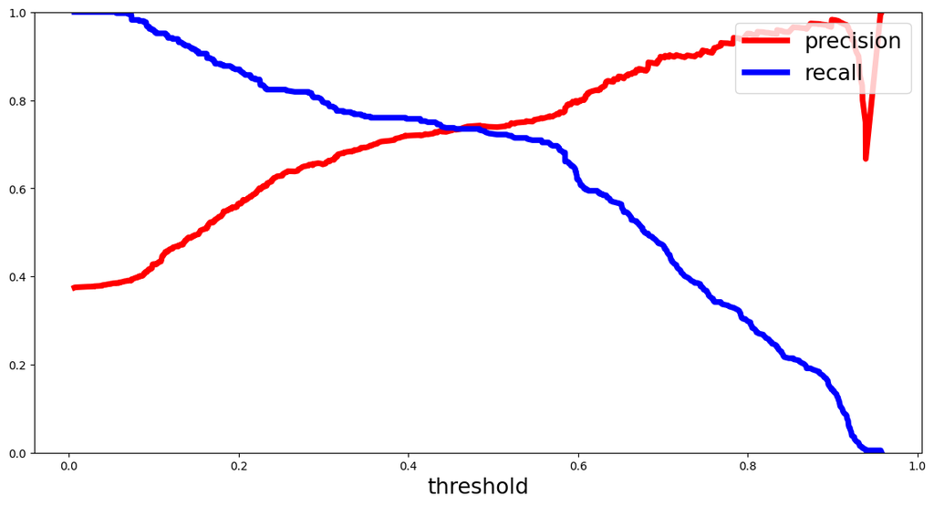

```python
def plot_precision_and_recall(precision, recall, threshold):
    plt.plot(threshold, precision[:-1], "r-", label="precision", linewidth=5)
    plt.plot(threshold, recall[:-1], "b", label="recall", linewidth=5)
    plt.xlabel("threshold", fontsize=19)
    plt.legend(loc="upper right", fontsize=19)
    plt.ylim([0, 1])

plt.figure(figsize=(14, 7))
plot_precision_and_recall(precision, recall, threshold)
plt.show()
```

## 20.6 Evaluation based on Receiver Operating Characteristic(ROC)

In this stage, the Receiver Operating Characteristic (ROC) curve is generated to illustrate the trade-off between true positive rate (TPR) and false positive rate (FPR) at different classification thresholds. The roc_curve function from scikit-learn is used to compute the TPR, FPR, and corresponding thresholds based on the model's predicted scores on the training dataset. Subsequently, a custom function plot_roc_curve is defined to represent the ROC curve visually. The function creates a line plot where the x-axis corresponds to the FPR, the y-axis to the TPR, and a red diagonal line represents the baseline. The resulting curve provides insights into the model's ability to distinguish between positive and negative instances. This graphical representation is essential for evaluating the model's overall classification performance.

```python
from sklearn.metrics import roc_curve
# compute true positive rate and false positive rate
false_positive_rate, true_positive_rate, thresholds = roc_curve(y_train, y_scores)
```

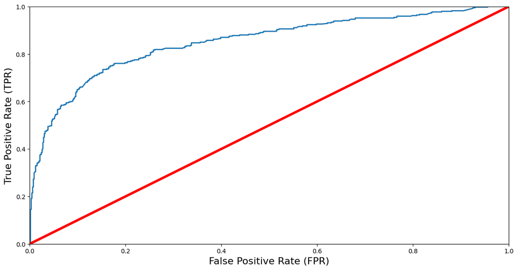

```python
# plotting them against each other
def plot_roc_curve(false_positive_rate, true_positive_rate, label=None):
    plt.plot(false_positive_rate, true_positive_rate, linewidth=2, label=label)
    plt.plot([0, 1], [0, 1], 'r', linewidth=4)
    plt.axis([0, 1, 0, 1])
    plt.xlabel('False Positive Rate (FPR)', fontsize=16)
    plt.ylabel('True Positive Rate (TPR)', fontsize=16)

plt.figure(figsize=(14, 7))
plot_roc_curve(false_positive_rate, true_positive_rate)
plt.show()
```

## 20.7 Evaluation on ROC-AUC-SCORE

```python
from sklearn.metrics import roc_auc_score
r_a_score = roc_auc_score(y_train, y_scores)
print("ROC-AUC-Score:", r_a_score)
```

```
ROC-AUC-Score: 0.8500447889079297
```

# 21 Building Machine Learning Models for comparison

```python
# Algorithms
from sklearn.ensemble import RandomForestClassifier
from sklearn.linear_model import LogisticRegression
from sklearn.neighbors import KNeighborsClassifier
from sklearn.naive_bayes import GaussianNB
from sklearn.svm import SVC, LinearSVC
from sklearn.tree import DecisionTreeClassifier

from sklearn.linear_model import Perceptron
from sklearn.linear_model import SGDClassifier
from sklearn import linear_model
```

## 21.1 Random Forest

I applied a Random Forest classifier to enhance the machine learning model. The RandomForestClassifier was configured with 100 decision trees (n_estimators=100). The model underwent training using the specified training dataset (x_train and y_train), and subsequent predictions were generated for the test dataset (x_test). The model's accuracy on the training data was evaluated using the scoring method, with the result rounded to two decimal places for clarity.

Assessing the model's accuracy on the training data revealed an impressive accuracy of 96.85%. This high percentage indicates the Random Forest model's exceptional proficiency in correctly classifying instances within the training dataset.

```python
random_forest = RandomForestClassifier(n_estimators=100)
random_forest.fit(x_train, y_train)

y_prediction = random_forest.predict(x_test)


acc_random_forest = round(random_forest.score(x_train, y_train) * 100, 2)
print("Accuracy on training set:", round(acc_random_forest, 2), "%")


acc_test_random_forest = round(random_forest.score(x_test, y_test) * 100, 2)
print("Accuracy on test set:", round(acc_test_random_forest, 2), "%")
```

```
Accuracy on training set: 96.85 %
Accuracy on test set: 79.39 %
```

## 21.2 Logistic Regression

At this stage, I worked with a Logistic Regression model using the training dataset (x_train and y_train). After training the model, I employed it to make predictions on the test dataset (x_test). Assessing the model's accuracy on the training data revealed an accuracy of 78.03%. This percentage indicates the Logistic Regression model's proficiency in correctly classifying instances within the training dataset, although slightly lower than the Random Forest model used in the comparison.

```python
logreg = LogisticRegression()
logreg.fit(x_train, y_train)

y_pred = logreg.predict(x_test)

acc_log = round(logreg.score(x_train, y_train) * 100, 2)
print("Accuracy on training",round(acc_log,2,), "%")

acc_test_log = round(logreg.score(x_test, y_test) * 100, 2)
print("Accuracy on testing",round(acc_test_log,2,), "%")
```

```
Accuracy on training 78.03 %
Accuracy on testing 82.44 %
```

## 21.3 K-Nearest Neighbors

```python
knn = KNeighborsClassifier(n_neighbors = 3)
knn.fit(x_train, y_train)

y_pred = knn.predict(x_test)

acc_knn = round(knn.score(x_train, y_train) * 100, 2)
print("Accuracy on training", round(acc_knn,2,), "%")

acc_test_knn = round(knn.score(x_test, y_test) * 100, 2)
print("Accuracy on testing", round(acc_test_knn,2,), "%")
```

```
Accuracy on training 86.06 %
Accuracy on testing 76.34 %
```

## 21.4 Gaussian Naive Bayes

Furthermore, the evaluation of the Gaussian Naive Bayes model on the test dataset revealed an accuracy of 78.24%. This metric indicates the model's adeptness at accurately predicting instances in previously unseen data. The consistently high accuracy on the training and testing sets suggests that the Gaussian Naive Bayes model generalises well to new instances, affirming its overall efficacy in handling classification tasks. The model demonstrates a balanced performance in capturing patterns within the training data and successfully applying them to novel situations, making it a reliable choice for classification tasks in this configuration.

```python
gaussian = GaussianNB()
gaussian.fit(x_train, y_train)

y_pred = gaussian.predict(x_test)

acc_gaussian = round(gaussian.score(x_train, y_train) * 100, 2)
print("Accuracy on training", round(acc_gaussian,2,), "%")

acc_test_gaussian = round(gaussian.score(x_test, y_test) * 100, 2)
print("Accuracy on testing", round(acc_test_gaussian,2,), "%")
```

```
Accuracy on training 78.51 %
Accuracy on testing 78.24 %
```

## 21.5 Decision Tree

I implemented a Decision Tree classifier using the scikit-learn library in this phase. The DecisionTreeClassifier was instantiated, and the model underwent training on the provided training dataset (x_train and y_train) using the fit method. Subsequently, predictions were generated for the test dataset (x_test) using the prediction method.

The model's accuracy was then calculated, revealing an impressive accuracy of 96.85% on the training set. This accuracy signifies the percentage of correctly predicted instances by the Decision Tree classifier based on the features present in the training data.

```python
decision_tree = DecisionTreeClassifier()
decision_tree.fit(x_train, y_train)

y_pred = decision_tree.predict(x_test)

acc_decision_tree = round(decision_tree.score(x_train, y_train) * 100, 2)
print("Accuracy on training ", round(acc_decision_tree,2,), "%")

acc_test_decision_tree = round(decision_tree.score(x_test, y_test) * 100, 2)
print("Accuracy on testing ", round(acc_test_decision_tree,2,), "%")
```

```
Accuracy on training  96.85 %
Accuracy on testing  77.48 %
```

# 22. Model Comparison

```python
results = pd.DataFrame({
    'Model': ['Random Forest', 'Logistic Regression', 'K-Nearest Neighbors',
              'Naive Bayes', 'Decision Tree'],
    'Train score': [acc_random_forest, acc_log, acc_knn, acc_gaussian,
                    acc_decision_tree],
    'Test Score': [acc_test_random_forest, acc_test_log, acc_test_knn, acc_test_gaussian,
                   acc_test_decision_tree]

})

# Sorting the DataFrame by the 'Test Score' column
result_df = results.sort_values(by='Test Score', ascending=False)
result_df = result_df.set_index('Model')
result_df.head(9)
```

| Model | Train score | Test Score |
| --- | --- | --- |
| Logistic Regression | 78.03 | 82.44 |
| Random Forest | 96.85 | 79.39 |
| Naive Bayes | 78.51 | 78.24 |
| Decision Tree | 96.85 | 77.48 |
| K-Nearest Neighbors | 86.06 | 76.34 |

**Random Forest** had the same accuracy as **decision tree** for training, with the highest metric out of all the other methods, showing 96.85%. it was the second best in terms of the test accuracy score, showing 79.39%, indicating it had a strong ability for generalising new unseen data well. however, the variance between the accuracy of the training and the testing gives us evidence that the model may have been susceptible to overfitting, even though it showed very high performance.

**Naive Bayes** provided accuracy scores of around the same value of 78.51 and 78.24 for the training and testing accuracy scores, respectively, showing a balanced performance from the model. A moderate accuracy suggested that the model may have yet to capture complex relationships as effectively as other machine learning models listed.

**Decision tree** had an exceptional metric for accuracy relating to the training score of 96.85%, suggesting the model's strong ability to learn from the data. The model's accuracy for the testing drops steeply, indicating a sign of possible overfitting. Meaning the model is unable to generalise well with new unseen data.

# Conclusion

My project has reflected on AI and the subset of AI being machine learning. I have explored the subsets of Machine learning and identified the compositional hierarchical architecture of machine learning, including supervised, unsupervised, and reinforcement learning. through this process, I have found a problem domain related to one of these types of learning. For my project, I decided to utilise supervised learning; I made an exploratory analysis of 5 different algorithms in supervised learning, including Random forest, Decision trees, Naive Bayes, KNN and Neural networks. briefly describe the strengths and weaknesses of the algorithms and relate the algorithms to how they may work with my problem domain.

The problem domain I chose was a dataset corresponding to the survival of passengers on the Titanic. This dataset has been a complicated task in preprocessing and collecting clean data for my predictive analysis. Initially, I had to convert the dataset from Excel to CSV, handle the missing data and normalise the samples to suit my model. Pandas were used for the preprocessing of my data. My greatest difficulty was finding a good correlation of features for my passengers to relate to my classification label, handling my missing data and understanding the meaning of the columns in the dataset. I explored 5 different methods for handling missing data for my age. I decided to use machine learning as the most suitable method to assume the passengers' missing age accurately. preprocessing was a new sector for me to explore in machine learning, and I gained satisfactory knowledge in exploring datasets by manipulating them and gaining valid information from them. For example, my dataset had imbalanced class labels as more people passed away than survived the Titanic. This may have had an impact on the accuracy results of my models. However, some factors may have affected my model's performance.

My modelling consisted of hyperparameter tuning, variations of the model architecture and checking metrics to see the model's performance, which was a multi-layer perceptron. Once I found the most suitable model for the predictive analysis, I used the MLP variation with strong testing and training accuracy, which showed no overfitting. I gave the model scenarios to test whether it performed well on unseen data. the evaluation explored results in the confusion matrix, which also gave me precision, recall and f1 score. These all showed me how the model correctly or incorrectly classified the class labels of the given passengers in the dataset. The F1 score gave me the model's balance between precision and recall. once my evaluation was over, I was not satisfied with the amount of research I had done into the provided supervised learning algorithms. I planned to use these to analyse further using a more suitable method for my problem domain.

I chose to employ these methods and report not only their training accuracy but also their testing accuracy. This process was insightful for me, as I saw how these models would react to my dataset and how well my models would perform in the training and testing processes. I chose Logistic Regression, Random Forest, Decision Tree, Naive Bayes and K-Nearest Neighbors to explore and evaluate their results.

This project deepened my knowledge of fundamental AI concepts and taught me practical skills in implementing and evaluating AI techniques across various sub-fields. It highlighted the significance of judiciously choosing algorithms based on problem domains, preparing data meticulously, and critically assessing the soundness of results—a skill set essential for effective AI implementation and application.